# The weight of Pokémon species - Initial data analysis

##### Descriptive statistics of selected variables, by Pokémon evolution phase

**RESULTS:** The Pokémon classified by the evolution phases differ by most of the variables. As expected, Pokémon in later evolution phases are stronger and heavier. Pokémon that do not evolve are similar to Phase 2 Pokémon (stronger in some aspects, mostly speed and total points), and they show more variability in most of the variables. The Pokémon that have special status generally do not evolve (evolving special Pokémon were first introduced in generation 7).

**CONSEQUENCES:** The strong association between the evolution phases and the other variables might indicate that the evolution phase might not be needed as an explanatory variable in the regression model.

| Characteristics by Pokémon evolution phase. | Characteristics by Pokémon evolution phase. Baby *N=17* | Characteristics by Pokémon evolution phase. Base *N=342* | Characteristics by Pokémon evolution phase. Phase1 *N=354* | Characteristics by Pokémon evolution phase. Phase2 *N=111* | Characteristics by Pokémon evolution phase. NotEvolving *N=201* |
| --- | --- | --- | --- | --- | --- |
| factor(generation) : 1 | 0.00 <sup>0</sup>⁄<sub>17</sub> | 0.20 <sup>68</sup>⁄<sub>342</sub> | 0.16 <sup>56</sup>⁄<sub>354</sub> | 0.14 <sup>16</sup>⁄<sub>111</sub> | 0.05 <sup>11</sup>⁄<sub>201</sub> |
| 2 | 0.47 <sup>8</sup>⁄<sub>17</sub> | 0.11 <sup>39</sup>⁄<sub>342</sub> | 0.08 <sup>30</sup>⁄<sub>354</sub> | 0.09 <sup>10</sup>⁄<sub>111</sub> | 0.06 <sup>13</sup>⁄<sub>201</sub> |
| 3 | 0.12 <sup>2</sup>⁄<sub>17</sub> | 0.13 <sup>45</sup>⁄<sub>342</sub> | 0.13 <sup>45</sup>⁄<sub>354</sub> | 0.14 <sup>15</sup>⁄<sub>111</sub> | 0.14 <sup>28</sup>⁄<sub>201</sub> |
| 4 | 0.41 <sup>7</sup>⁄<sub>17</sub> | 0.08 <sup>26</sup>⁄<sub>342</sub> | 0.12 <sup>43</sup>⁄<sub>354</sub> | 0.11 <sup>12</sup>⁄<sub>111</sub> | 0.09 <sup>19</sup>⁄<sub>201</sub> |
| 5 | 0.00 <sup>0</sup>⁄<sub>17</sub> | 0.16 <sup>56</sup>⁄<sub>342</sub> | 0.16 <sup>55</sup>⁄<sub>354</sub> | 0.17 <sup>19</sup>⁄<sub>111</sub> | 0.13 <sup>26</sup>⁄<sub>201</sub> |
| 6 | 0.00 <sup>0</sup>⁄<sub>17</sub> | 0.08 <sup>26</sup>⁄<sub>342</sub> | 0.08 <sup>27</sup>⁄<sub>354</sub> | 0.07 <sup>8</sup>⁄<sub>111</sub> | 0.05 <sup>11</sup>⁄<sub>201</sub> |
| 7 | 0.00 <sup>0</sup>⁄<sub>17</sub> | 0.07 <sup>24</sup>⁄<sub>342</sub> | 0.07 <sup>24</sup>⁄<sub>354</sub> | 0.08 <sup>9</sup>⁄<sub>111</sub> | 0.15 <sup>31</sup>⁄<sub>201</sub> |
| 8 | 0.00 <sup>0</sup>⁄<sub>17</sub> | 0.08 <sup>27</sup>⁄<sub>342</sub> | 0.10 <sup>37</sup>⁄<sub>354</sub> | 0.10 <sup>11</sup>⁄<sub>111</sub> | 0.10 <sup>21</sup>⁄<sub>201</sub> |
| 9 | 0.00 <sup>0</sup>⁄<sub>17</sub> | 0.09 <sup>31</sup>⁄<sub>342</sub> | 0.10 <sup>37</sup>⁄<sub>354</sub> | 0.10 <sup>11</sup>⁄<sub>111</sub> | 0.20 <sup>41</sup>⁄<sub>201</sub> |
| height_m | 0.300 0.500 0.600 0.476 ± 0.225 | 0.400 0.500 0.700 0.633 ± 0.572 | 0.800 1.100 1.500 1.326 ± 1.094 | 1.300 1.600 1.900 1.635 ± 0.563 | 0.700 1.500 2.000 1.829 ± 2.000 |
| special_status : normal | 1.00 <sup>17</sup>⁄<sub>17</sub> | 0.99 <sup>337</sup>⁄<sub>342</sub> | 0.99 <sup>349</sup>⁄<sub>354</sub> | 0.98 <sup>109</sup>⁄<sub>111</sub> | 0.54 <sup>108</sup>⁄<sub>201</sub> |
| sub-legendary | 0.00 <sup>0</sup>⁄<sub>17</sub> | 0.01 <sup>3</sup>⁄<sub>342</sub> | 0.01 <sup>3</sup>⁄<sub>354</sub> | 0.00 <sup>0</sup>⁄<sub>111</sub> | 0.22 <sup>45</sup>⁄<sub>201</sub> |
| legendary | 0.00 <sup>0</sup>⁄<sub>17</sub> | 0.00 <sup>1</sup>⁄<sub>342</sub> | 0.00 <sup>1</sup>⁄<sub>354</sub> | 0.02 <sup>2</sup>⁄<sub>111</sub> | 0.13 <sup>27</sup>⁄<sub>201</sub> |
| mythical | 0.00 <sup>0</sup>⁄<sub>17</sub> | 0.00 <sup>1</sup>⁄<sub>342</sub> | 0.00 <sup>1</sup>⁄<sub>354</sub> | 0.00 <sup>0</sup>⁄<sub>111</sub> | 0.10 <sup>21</sup>⁄<sub>201</sub> |
| hp | 40.0 45.0 50.0 55.6 ± 30.9 | 40.0 49.5 60.0 51.5 ± 21.0 | 60.0 70.0 85.0 75.6 ± 22.8 | 75.0 80.0 95.0 85.1 ± 18.0 | 70.0 82.0 100.0 85.4 ± 26.2 |
| attack | 23.0 30.0 40.0 37.4 ± 23.5 | 44.2 55.0 66.8 56.3 ± 19.7 | 65.0 80.5 100.0 83.6 ± 25.5 | 80.0 100.0 118.5 98.0 ± 25.9 | 75.0 96.0 115.0 95.0 ± 28.3 |
| defense | 28.0 37.0 48.0 38.5 ± 21.2 | 40.0 50.0 60.0 53.0 ± 20.5 | 60.0 70.0 90.0 77.9 ± 26.2 | 71.5 85.0 96.5 87.3 ± 22.2 | 71.0 90.0 105.0 90.9 ± 29.9 |
| sp_attack | 35.0 40.0 65.0 45.2 ± 21.5 | 35.0 45.0 60.0 49.4 ± 18.8 | 55.0 71.0 95.0 75.4 ± 24.6 | 70.0 90.0 108.5 88.1 ± 25.6 | 65.0 85.0 115.0 88.0 ± 33.1 |
| sp_defense | 45.0 55.0 65.0 58.7 ± 23.8 | 40.0 48.0 56.0 50.5 ± 18.3 | 60.0 70.0 82.8 74.2 ± 21.5 | 75.0 85.0 95.0 85.7 ± 18.8 | 70.0 89.0 101.0 89.2 ± 28.4 |
| speed | 20.0 35.0 60.0 40.4 ± 26.5 | 35.0 50.0 65.0 51.3 ± 20.6 | 50.0 67.5 90.0 69.8 ± 27.3 | 60.0 79.0 96.0 78.1 ± 24.5 | 70.0 90.0 103.0 86.0 ± 29.5 |
| total | 218.0 280.0 310.0 275.8 ± 63.2 | 280.0 306.5 330.0 311.9 ± 60.5 | 415.8 474.0 500.0 456.5 ± 62.6 | 500.0 525.0 534.0 522.3 ± 47.6 | 475.0 570.0 590.0 534.5 ± 87.3 |
| catch_rate | 50.00 130.00 170.00 127.35 ± 72.11 | 71.25 190.00 232.50 161.60 ± 80.25 | 45.00 60.00 90.00 70.57 ± 32.30 | 45.00 45.00 45.00 43.50 ± 8.65 | 3.00 30.00 50.00 50.46 ± 66.18 |
| gender_cat : Equal | 0.41 <sup>7</sup>⁄<sub>17</sub> | 0.72 <sup>245</sup>⁄<sub>342</sub> | 0.70 <sup>249</sup>⁄<sub>354</sub> | 0.59 <sup>66</sup>⁄<sub>111</sub> | 0.32 <sup>64</sup>⁄<sub>201</sub> |
| Mostly female | 0.29 <sup>5</sup>⁄<sub>17</sub> | 0.06 <sup>20</sup>⁄<sub>342</sub> | 0.06 <sup>23</sup>⁄<sub>354</sub> | 0.05 <sup>6</sup>⁄<sub>111</sub> | 0.05 <sup>10</sup>⁄<sub>201</sub> |
| Mostly male | 0.29 <sup>5</sup>⁄<sub>17</sub> | 0.18 <sup>61</sup>⁄<sub>342</sub> | 0.18 <sup>64</sup>⁄<sub>354</sub> | 0.30 <sup>33</sup>⁄<sub>111</sub> | 0.06 <sup>13</sup>⁄<sub>201</sub> |
| Genderless | 0.00 <sup>0</sup>⁄<sub>17</sub> | 0.05 <sup>16</sup>⁄<sub>342</sub> | 0.05 <sup>18</sup>⁄<sub>354</sub> | 0.05 <sup>6</sup>⁄<sub>111</sub> | 0.57 <sup>114</sup>⁄<sub>201</sub> |
| happiness_cat : Happy | 0.12 <sup>2</sup>⁄<sub>17</sub> | 0.01 <sup>4</sup>⁄<sub>342</sub> | 0.02 <sup>6</sup>⁄<sub>354</sub> | 0.00 <sup>0</sup>⁄<sub>111</sub> | 0.11 <sup>22</sup>⁄<sub>201</sub> |
| Normal | 0.88 <sup>15</sup>⁄<sub>17</sub> | 0.91 <sup>312</sup>⁄<sub>342</sub> | 0.90 <sup>318</sup>⁄<sub>354</sub> | 0.88 <sup>98</sup>⁄<sub>111</sub> | 0.46 <sup>92</sup>⁄<sub>201</sub> |
| Unhappy | 0.00 <sup>0</sup>⁄<sub>17</sub> | 0.08 <sup>26</sup>⁄<sub>342</sub> | 0.08 <sup>30</sup>⁄<sub>354</sub> | 0.12 <sup>13</sup>⁄<sub>111</sub> | 0.43 <sup>87</sup>⁄<sub>201</sub> |

*a* *b* *c* represent the lower quartile *a*, the median *b*, and the upper quartile *c* for continuous variables. *x ± s* represents X ± 1 SD.

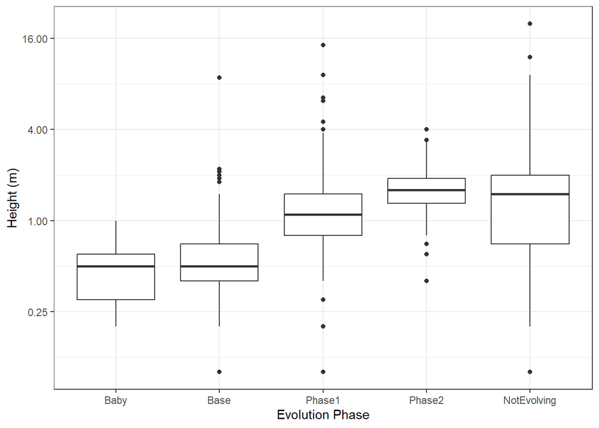

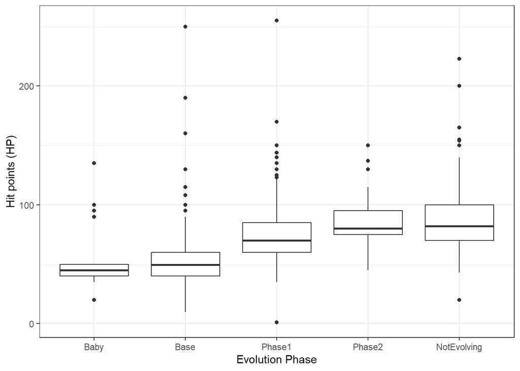

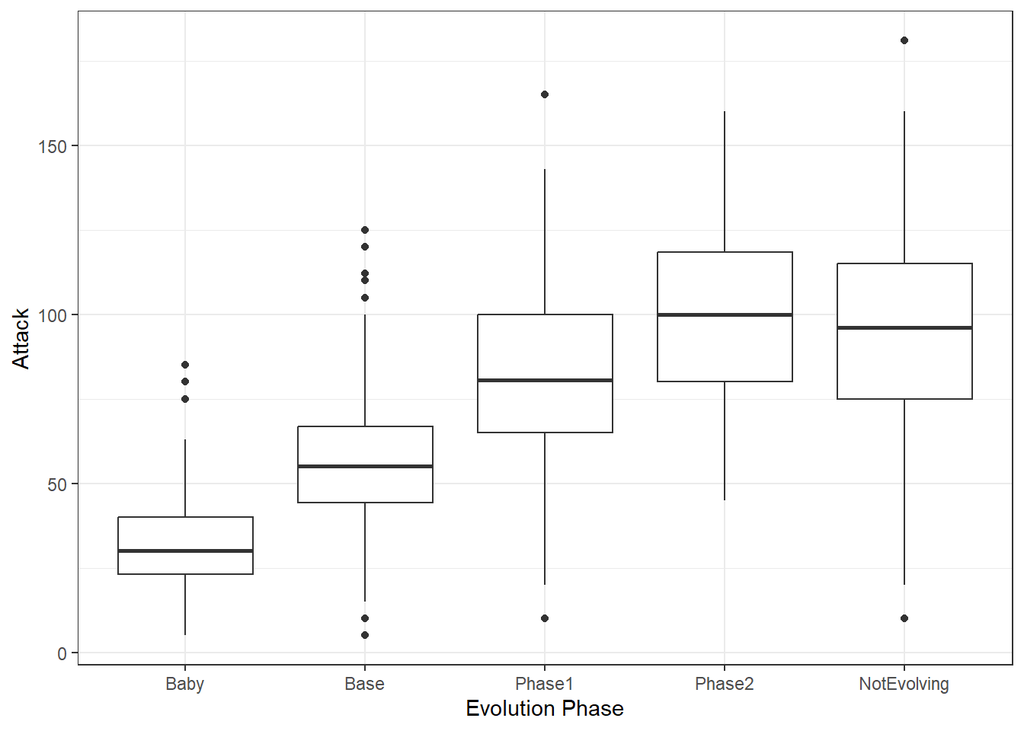

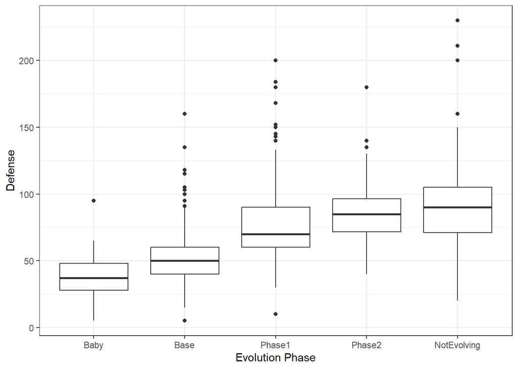

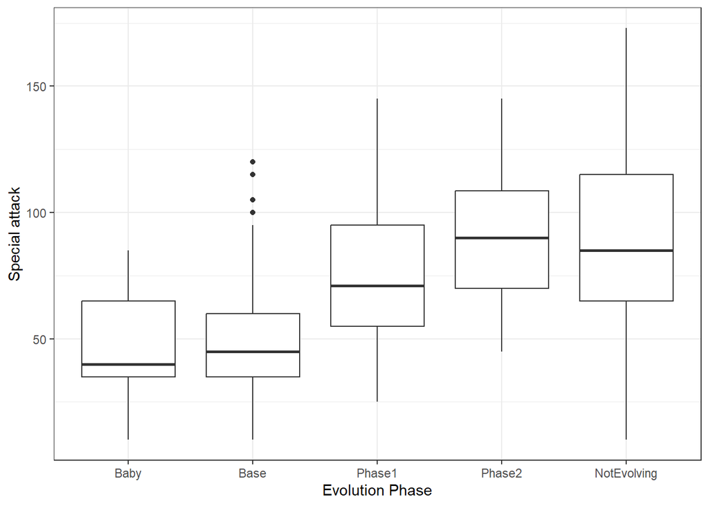

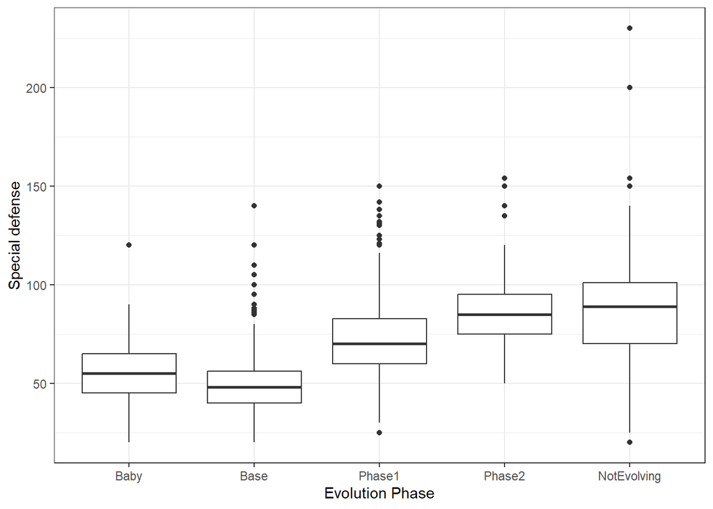

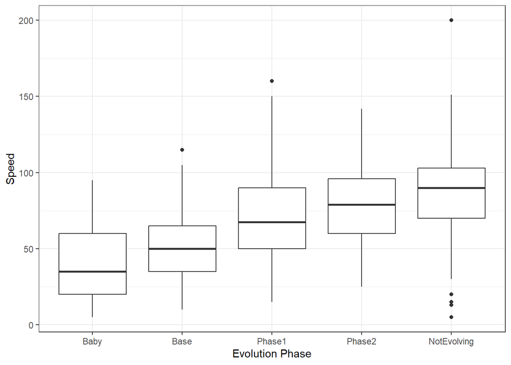

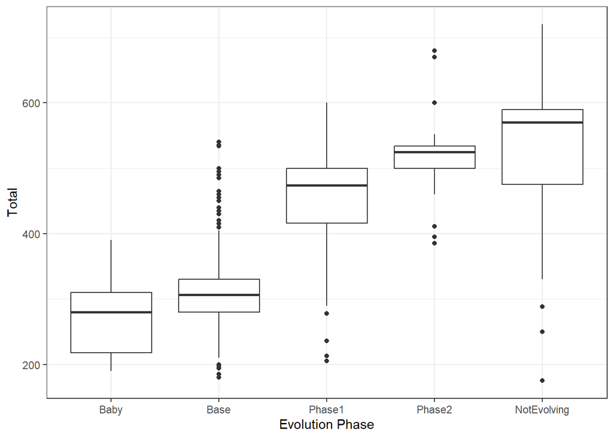

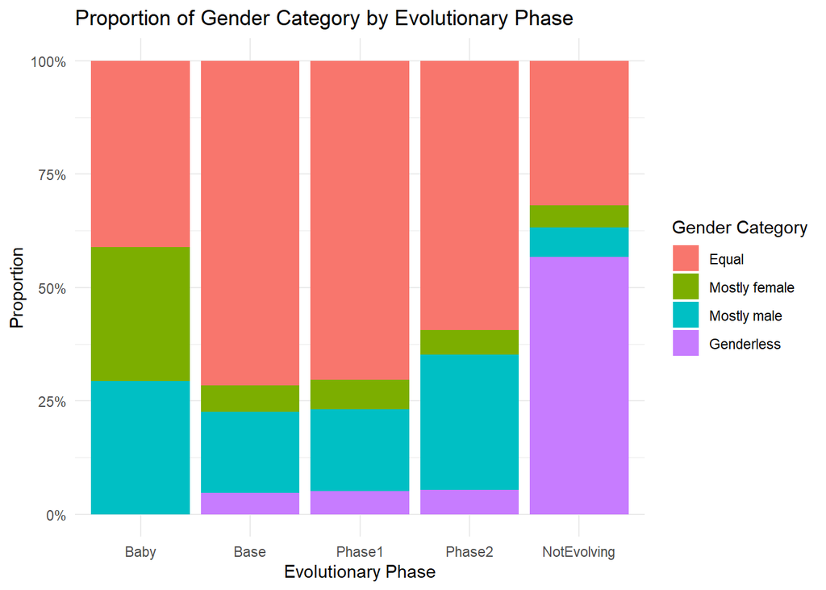

```r
# 1. Evolutionary Phase vs Gender Category
ggplot(pokemon, aes(x = factor(PokemonPhase_5cat), fill = gender_cat)) +
  geom_bar(position = "fill") +
  scale_y_continuous(labels = percent_format()) +
  labs(
    x = "Evolutionary Phase",
    y = "Proportion",
    fill = "Gender Category",
    title = "Proportion of Gender Category by Evolutionary Phase"
  ) +
  theme_minimal()
```

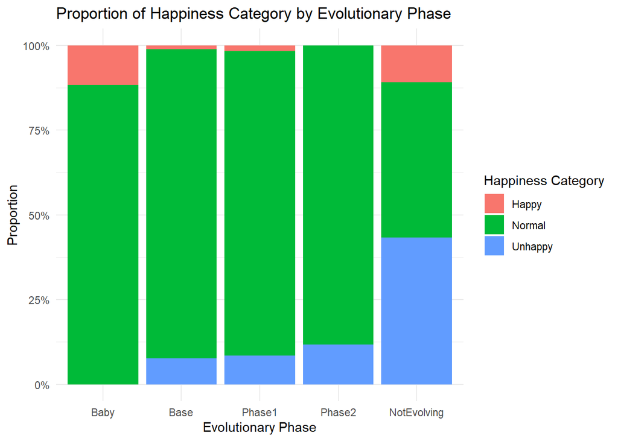

```r
# 2. Evolutionary Phase vs Happiness Category
ggplot(pokemon, aes(x = factor(PokemonPhase_5cat), fill = happiness_cat)) +
  geom_bar(position = "fill") +
  scale_y_continuous(labels = percent_format()) +
  labs(
    x = "Evolutionary Phase",
    y = "Proportion",
    fill = "Happiness Category",
    title = "Proportion of Happiness Category by Evolutionary Phase"
  ) +
  theme_minimal()
```

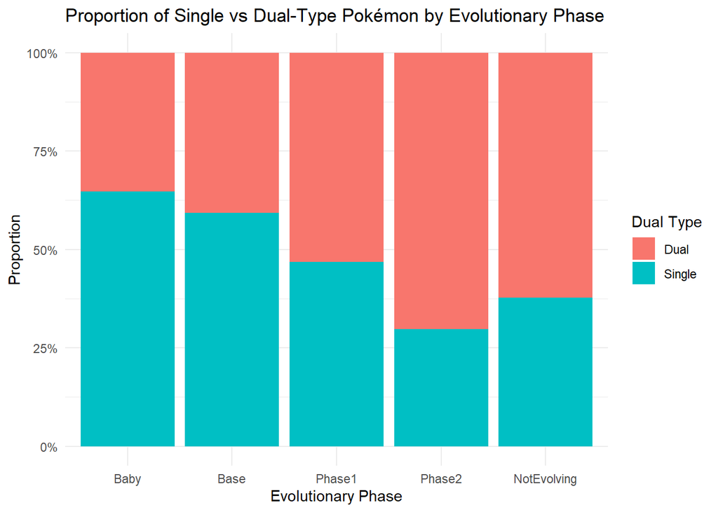

```r
# 4. Evolutionary Phase vs Dual Type
ggplot(pokemon, aes(x = factor(PokemonPhase_5cat), fill = as.factor(dual_type))) +
  geom_bar(position = "fill") +
  scale_y_continuous(labels = percent_format()) +
  labs(
    x = "Evolutionary Phase",
    y = "Proportion",
    fill = "Dual Type",
    title = "Proportion of Single vs Dual-Type Pokémon by Evolutionary Phase"
  ) +
  theme_minimal()
```

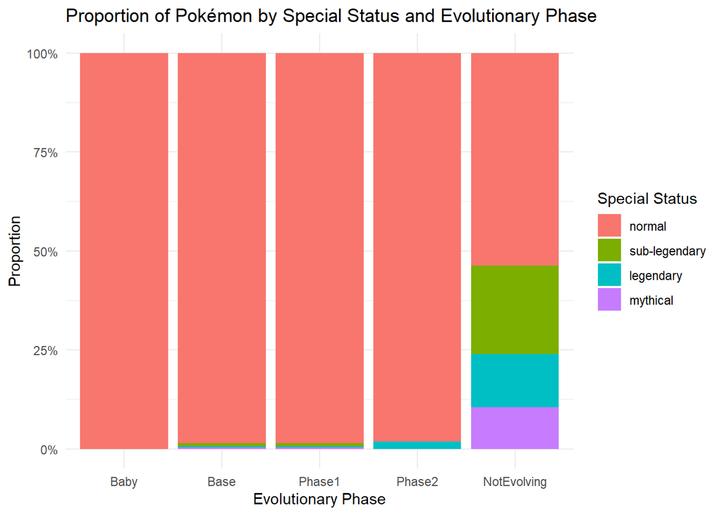

```r
# 5. Evolutionary Phase vs Special Status
ggplot(pokemon, aes(x = factor(PokemonPhase_5cat), fill = special_status)) +
  geom_bar(position = "fill") +
  scale_y_continuous(labels = percent_format()) +
  labs(
    x = "Evolutionary Phase",
    y = "Proportion",
    fill = "Special Status",
    title = "Proportion of Pokémon by Special Status and Evolutionary Phase"
  ) +
  theme_minimal()
```

##### Descriptive statistics of selected variables, by gender

Here we describe the characteristic of the Pokémon by gender.

**COMMENT:** A subgroup analysis is planned by gender category.

**RESULT:** The genderless category differs most from the other categories. The mostly female category are the shortest species.

| Characteristics by gender. | Characteristics by gender. Equal *N=631* | Characteristics by gender. Mostly female *N=64* | Characteristics by gender. Mostly male *N=176* | Characteristics by gender. Genderless *N=154* |
| --- | --- | --- | --- | --- |
| PokemonPhase_5cat : Baby | 0.01 <sup>7</sup>⁄<sub>631</sub> | 0.08 <sup>5</sup>⁄<sub>64</sub> | 0.03 <sup>5</sup>⁄<sub>176</sub> | 0.00 <sup>0</sup>⁄<sub>154</sub> |
| Base | 0.39 <sup>245</sup>⁄<sub>631</sub> | 0.31 <sup>20</sup>⁄<sub>64</sub> | 0.35 <sup>61</sup>⁄<sub>176</sub> | 0.10 <sup>16</sup>⁄<sub>154</sub> |
| Phase1 | 0.39 <sup>249</sup>⁄<sub>631</sub> | 0.36 <sup>23</sup>⁄<sub>64</sub> | 0.36 <sup>64</sup>⁄<sub>176</sub> | 0.12 <sup>18</sup>⁄<sub>154</sub> |
| Phase2 | 0.10 <sup>66</sup>⁄<sub>631</sub> | 0.09 <sup>6</sup>⁄<sub>64</sub> | 0.19 <sup>33</sup>⁄<sub>176</sub> | 0.04 <sup>6</sup>⁄<sub>154</sub> |
| NotEvolving | 0.10 <sup>64</sup>⁄<sub>631</sub> | 0.16 <sup>10</sup>⁄<sub>64</sub> | 0.07 <sup>13</sup>⁄<sub>176</sub> | 0.74 <sup>114</sup>⁄<sub>154</sub> |
| height_m | 0.500 0.900 1.400 1.108 ± 1.089 | 0.500 0.650 1.200 0.833 ± 0.481 | 0.600 1.000 1.500 1.082 ± 0.553 | 0.600 1.500 2.375 1.949 ± 2.104 |
| special_status : normal | 1.00 <sup>629</sup>⁄<sub>631</sub> | 0.94 <sup>60</sup>⁄<sub>64</sub> | 0.95 <sup>167</sup>⁄<sub>176</sub> | 0.42 <sup>64</sup>⁄<sub>154</sub> |
| sub-legendary | 0.00 <sup>1</sup>⁄<sub>631</sub> | 0.05 <sup>3</sup>⁄<sub>64</sub> | 0.03 <sup>6</sup>⁄<sub>176</sub> | 0.27 <sup>41</sup>⁄<sub>154</sub> |
| legendary | 0.00 <sup>1</sup>⁄<sub>631</sub> | 0.02 <sup>1</sup>⁄<sub>64</sub> | 0.02 <sup>3</sup>⁄<sub>176</sub> | 0.17 <sup>26</sup>⁄<sub>154</sub> |
| mythical | 0.00 <sup>0</sup>⁄<sub>631</sub> | 0.00 <sup>0</sup>⁄<sub>64</sub> | 0.00 <sup>0</sup>⁄<sub>176</sub> | 0.15 <sup>23</sup>⁄<sub>154</sub> |
| hp | 50.0 65.0 80.0 66.4 ± 24.1 | 53.5 69.0 80.0 74.7 ± 38.3 | 54.0 66.5 80.0 68.9 ± 22.0 | 67.0 88.5 100.0 85.3 ± 29.8 |
| attack | 53.0 71.0 95.0 74.2 ± 28.4 | 40.8 55.0 75.2 58.5 ± 26.6 | 60.0 80.0 102.5 81.3 ± 27.3 | 73.2 95.0 120.0 94.6 ± 31.2 |
| defense | 50.0 65.0 85.0 69.8 ± 29.0 | 45.0 62.0 75.0 60.6 ± 25.4 | 50.0 65.0 80.0 68.5 ± 23.6 | 75.0 95.0 109.5 93.2 ± 29.0 |
| sp_attack | 44.5 60.0 80.0 63.3 ± 26.1 | 45.0 64.5 82.8 68.3 ± 29.1 | 53.0 66.5 95.0 73.1 ± 27.0 | 70.5 95.0 124.8 95.3 ± 32.5 |
| sp_defense | 45.5 61.0 80.0 64.8 ± 24.6 | 55.0 70.0 96.5 75.8 ± 28.6 | 51.5 65.0 85.0 69.4 ± 22.2 | 75.0 90.0 107.8 91.0 ± 28.0 |
| speed | 40.0 60.0 80.0 62.1 ± 26.9 | 40.8 63.0 90.0 65.2 ± 28.9 | 50.0 65.0 85.0 69.5 ± 25.1 | 62.0 90.0 105.8 86.3 ± 31.5 |
| total | 309.5 420.0 485.0 400.6 ± 100.6 | 300.0 427.0 490.0 403.0 ± 109.1 | 350.0 420.0 525.0 430.7 ± 94.4 | 505.8 570.0 600.0 545.6 ± 105.2 |
| catch_rate | 45.0 90.0 190.0 117.9 ± 76.5 | 45.0 75.0 175.0 106.5 ± 74.6 | 45.0 45.0 45.0 58.6 ± 44.4 | 3.0 10.0 45.0 37.9 ± 58.1 |
| happiness_cat : Happy | 0.01 <sup>9</sup>⁄<sub>631</sub> | 0.12 <sup>8</sup>⁄<sub>64</sub> | 0.03 <sup>5</sup>⁄<sub>176</sub> | 0.08 <sup>12</sup>⁄<sub>154</sub> |
| Normal | 0.90 <sup>570</sup>⁄<sub>631</sub> | 0.84 <sup>54</sup>⁄<sub>64</sub> | 0.93 <sup>164</sup>⁄<sub>176</sub> | 0.31 <sup>47</sup>⁄<sub>154</sub> |
| Unhappy | 0.08 <sup>52</sup>⁄<sub>631</sub> | 0.03 <sup>2</sup>⁄<sub>64</sub> | 0.04 <sup>7</sup>⁄<sub>176</sub> | 0.62 <sup>95</sup>⁄<sub>154</sub> |

*a* *b* *c* represent the lower quartile *a*, the median *b*, and the upper quartile *c* for continuous variables. *x ± s* represents X ± 1 SD.

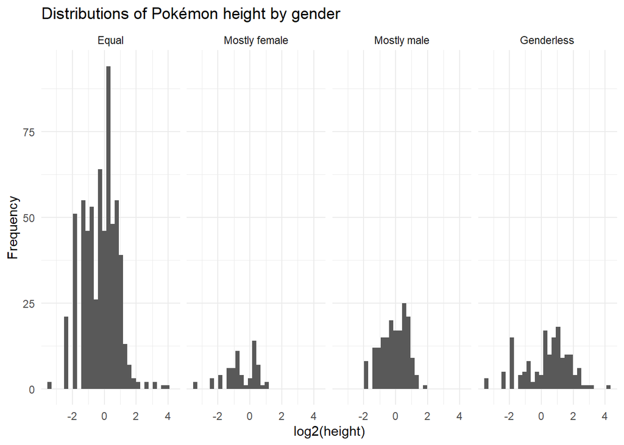

##### Association of selected variables with height

**RESULTS:** Most of the attack/defense variables are strongly and positively associated to height in the middle ranges of the values of height, while the association sometimes is not present for the most extreme values of height (height is log-2 transformed). The estimates are rather imprecise for values of height above 4 m, as few Pokémon are as high.

**CONSEQUENCES:** The non-linear association between base stats and (log2) height might anticipate non-linear associations also with the outcome variable.

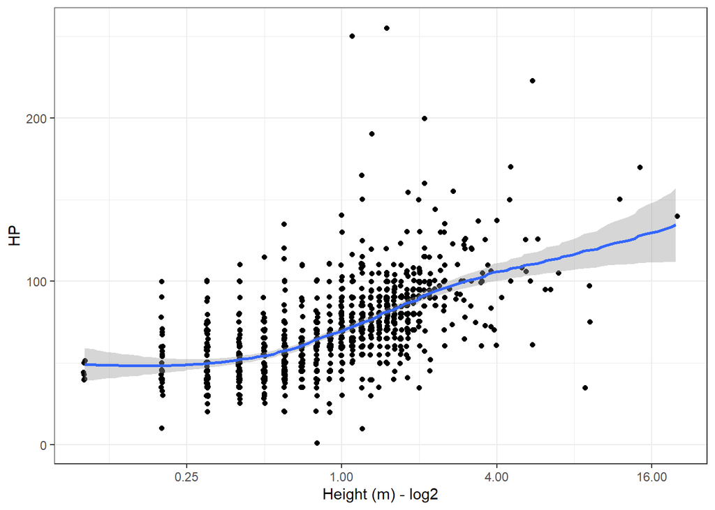

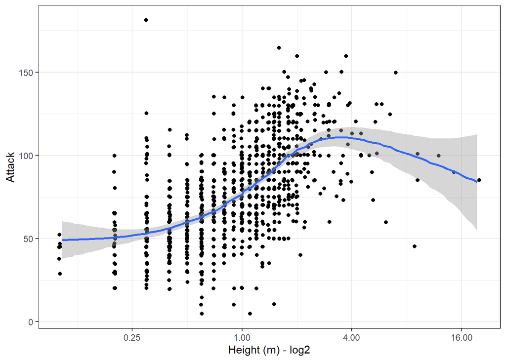

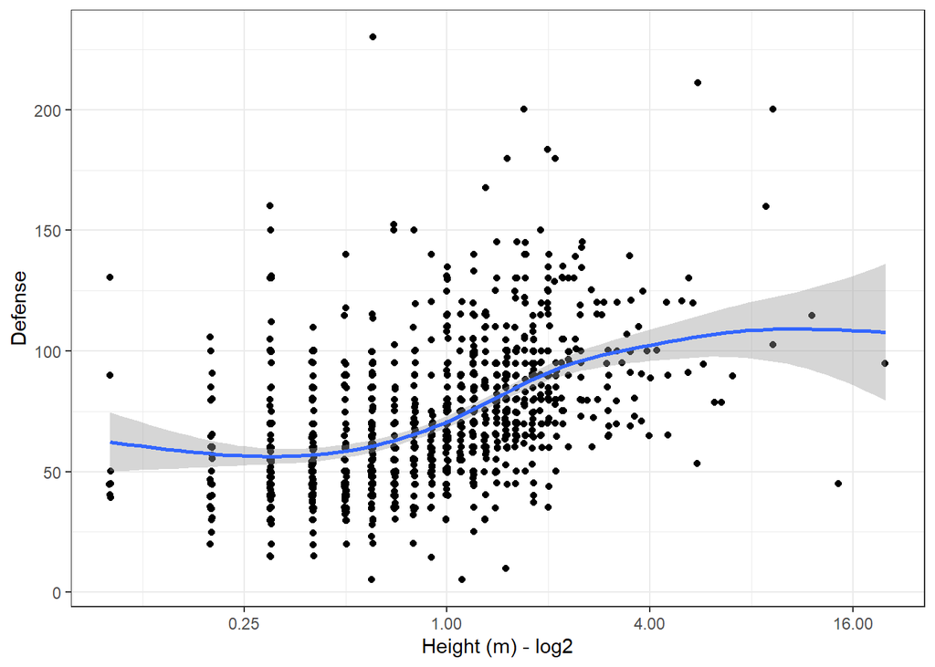

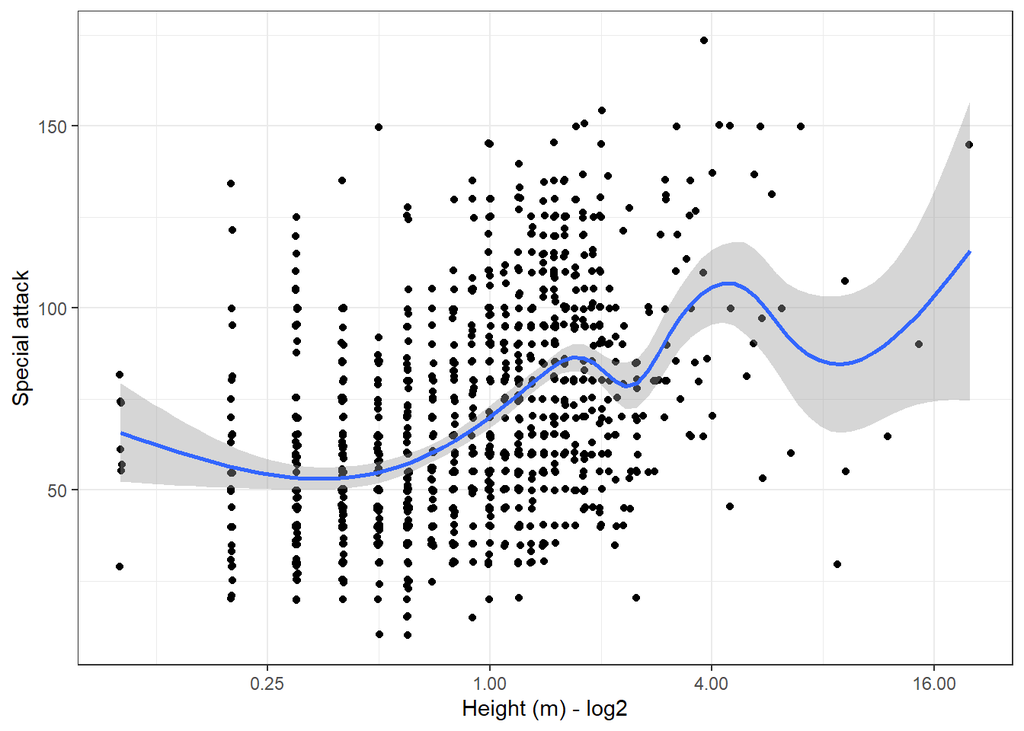

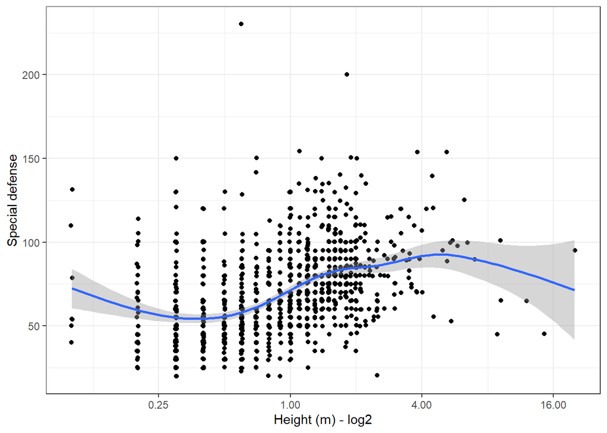

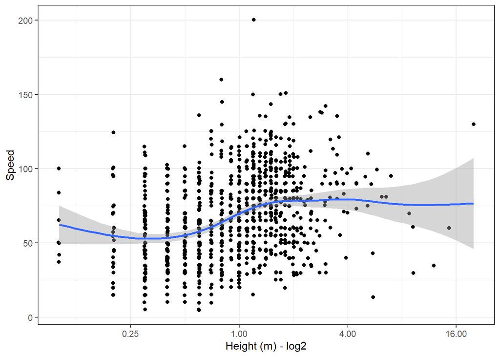

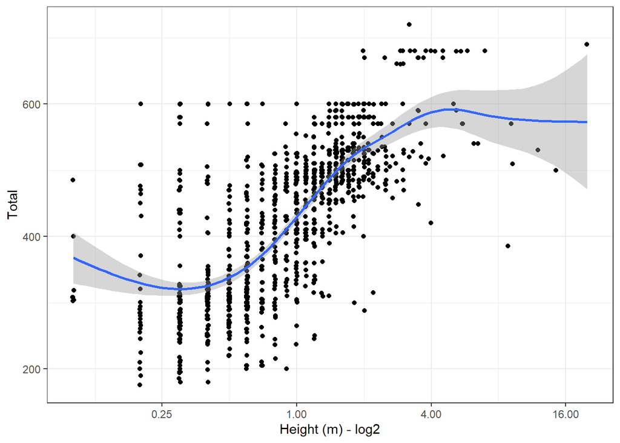

#### Correlation between explanatory variables

We use the generalized pairs plot to display the associations (summarized also with Pearson’s correlation) among numerical variables.

**COMMENT:** Total is the sum of hp, attack, defense, sp_defense, sp_attack and speed; therefore, a strong positive correlation of Total with these variables is expected. In regression modeling a choice must be made between the use of total or of the other six base stats.

**RESULT:** Most of the numerical variables were positively correlated; speed was weakly correlated to defense and height, and in general it was the least correlated variable to the other base stats and to total. Height was very strongly correlated to total, and generally positively associated to the other base stats (but the correlation was weaker than with total).

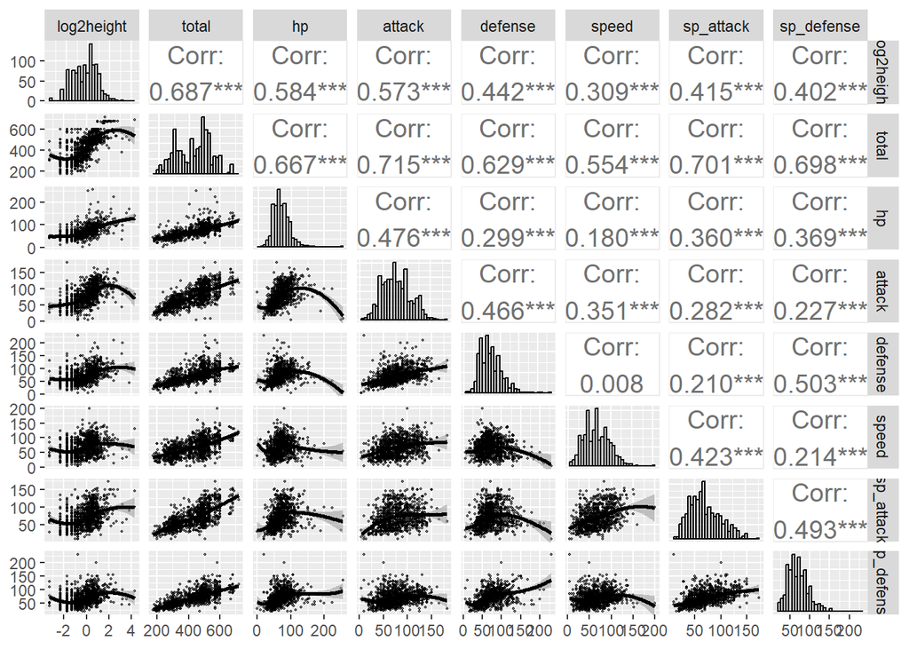

```r
#GGally::ggpairs(pokemon[,c(11:18,26)])

my.data <- cbind.data.frame(log2height= log2(pokemon$height_m),  pokemon %>% select("total", "hp", "attack", "defense", "speed", "sp_attack", "sp_defense"))
# Create plot with larger correlation text in upper panel
pair_plot <- GGally::ggpairs(
  my.data,
  aes(alpha = 0.1),
  lower = list(continuous = wrap("smooth", method = "loess", size = 0.3)),
  upper = list(continuous = wrap("cor", size = 5)),  # <- Increased from 3 to 5
  diag = list(continuous = wrap("barDiag", colour = "black", fill = "grey70"))
) #+my_theme

pair_plot
```

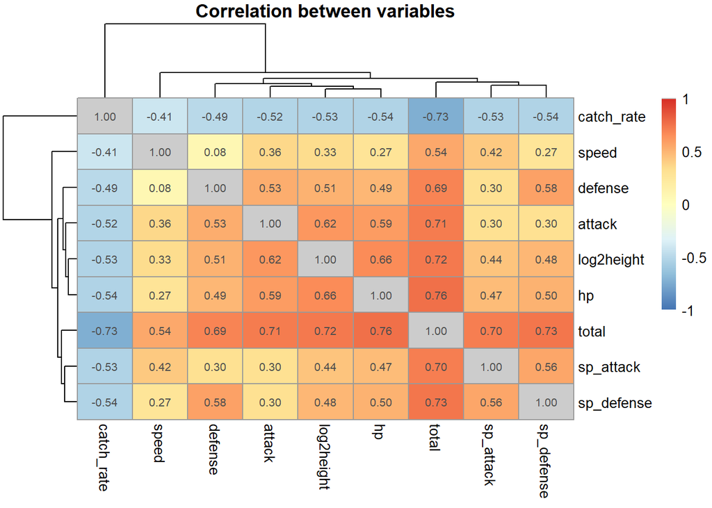

```r
my.data <- cbind.data.frame(log2height= log2(pokemon$height_m),  pokemon %>% select("total", "hp", "attack", "defense", "speed", "sp_attack", "sp_defense",  "catch_rate" ))



#setting the breaks for the heatmaps, to make colors comparable
Breaks <- seq(-1, 1, by=.01)
# selecting a color palette, setting 1 to gray
my_palette <- c( colorRampPalette( rev(RColorBrewer::brewer.pal(n = 7, name ="RdYlBu")))(length(Breaks)-2) , "grey80", "grey80")


pheatmap(cor(my.data, use="p", method="s"), cluster_cols=TRUE, cluster_rows=TRUE, display_numbers = TRUE, main="Correlation between variables", breaks=Breaks,
         #labels_row = paste("Wave", 1:7),  labels_col = paste("Wave", 1:7),
         color= my_palette)
```

Below we show graphically the association between total and the variables that constitute them, using different colors for the mythical, legendary/sub-legendary and normal groups. We also highlight the names of the Pokémon with unusual combinations of the values variables, which might be multivariable outliers.

**RESULTS:** The base stats variables are generally strongly associated to total, but not necessarily over the whole range of their values (total does not increase with HP, special defense and defense for their large values, some Pokémon can have large/low values of one variable but not necessarily also in the total). The base stats are less associated to height compared to total. The six base stats seem to carry additional information compared to Total, speed has distinct features from others, for example speed and defense have an extremely low correlation.

Catch rate and happiness (to a lesser extent) were negatively associated to the other variables (as higher values are generally associated to stronger Pokémon).

From the graphs it can also be seen that legendary Pokémon have consistently large values of total (only few legendary Pokémon have low values, Cosmoem, Cosmog and Terapagos) and that their values in the base stats is rather homogeneous, while there is more heterogeneity for mythical and sub-legendary Pokémon.

**CONSEQUENCES:** The association between the base stats and total is approximated fairly by a linear relationship for attack, speed and special attack, while the association is not visible for large values of HP, defense and special defense; some Pokémon with very large values of these variables do not have also a very large total.

In regression model the use of the six base stats might be more informative than the use of total, as the six base stats provide to some extents some heterogeneous information about the Pokémon strengths. It is however possible that the correlation between the base stats might inflate the standard errors of the estimated coefficient, or cause some instability in the model, or that some of the variables will not contribute to improve prediction (for example special attack and special defense, see also the graphs in the next section).

The very large (negative) correlation between catch rate and the base stats indicates that the use of this variable in modeling might not contribute much to prediction.

```r
pokemon$log2height <- log2(pokemon$height_m)
which.variables <- c("log2height", "total", "hp", "attack", "defense", "speed", "sp_attack", "sp_defense", "catch_rate")

my.mat <- cor(pokemon[, which.variables], use="p", method="s")
diag(my.mat) <- apply(pokemon[, which.variables], 2, sd, na.rm=TRUE)
my.mat[lower.tri(my.mat)] <- cov(pokemon[, which.variables], use="p")[lower.tri(cov(pokemon[, which.variables], use="p"))]

kable(my.mat, digits=2, caption="Correlation (upper triangle, Spearman) / SD (diagonal) / covariance (lower triangle) between variables") %>%
  kable_styling()
```

Correlation (upper triangle, Spearman) / SD (diagonal) / covariance (lower triangle) between variables

|  | log2height | total | hp | attack | defense | speed | sp_attack | sp_defense | catch_rate |
| --- | --- | --- | --- | --- | --- | --- | --- | --- | --- |
| log2height | 1.07 | 0.72 | 0.66 | 0.62 | 0.51 | 0.33 | 0.44 | 0.48 | -0.53 |
| total | 83.19 | 112.77 | 0.76 | 0.71 | 0.69 | 0.54 | 0.70 | 0.73 | -0.73 |
| hp | 16.70 | 2003.52 | 26.63 | 0.59 | 0.49 | 0.27 | 0.47 | 0.50 | -0.54 |
| attack | 18.32 | 2399.02 | 377.65 | 29.77 | 0.53 | 0.36 | 0.30 | 0.30 | -0.52 |
| defense | 13.91 | 2078.94 | 233.21 | 405.97 | 29.29 | 0.08 | 0.30 | 0.58 | -0.49 |
| speed | 9.54 | 1793.45 | 137.56 | 300.16 | 6.77 | 28.72 | 0.42 | 0.27 | -0.41 |
| sp_attack | 13.22 | 2345.08 | 284.04 | 249.11 | 182.50 | 360.40 | 29.66 | 0.56 | -0.53 |
| sp_defense | 11.49 | 2097.24 | 261.84 | 179.66 | 392.76 | 163.88 | 389.41 | 26.64 | -0.54 |
| catch_rate | -42.17 | -6298.50 | -997.54 | -1177.22 | -1024.29 | -865.52 | -1182.86 | -1051.06 | 76.36 |

#### Identification of species with unusual combinations of base stats

To identify Pokémon species with unusual combinations of base stats in a systematic and reproducible way, we define a profile imbalance index: each of the six base stats is standardized (z-scores, computed across all 1,025 species), and for each Pokémon species we compute the standard deviation of its own six standardized values. A low value indicates a balanced profile (similar standing across all six stats relative to other species); a high value indicates an imbalanced profile, combining an extreme value in one or more stats with comparatively low values in others. We identify the ten species with the highest profile imbalance index.

Pokémon species with the most unbalanced combination of base stats

| name | hp | attack | defense | sp_attack | sp_defense | speed | profile_imbalance |
| --- | --- | --- | --- | --- | --- | --- | --- |
| Shuckle | 20 | 10 | 230 | 10 | 230 | 5 | 4.02 |
| Blissey | 255 | 10 | 10 | 75 | 135 | 55 | 3.47 |
| Chansey | 250 | 5 | 5 | 35 | 105 | 50 | 3.46 |
| Guzzlord | 223 | 101 | 53 | 97 | 53 | 43 | 2.50 |
| Stakataka | 61 | 131 | 211 | 53 | 101 | 13 | 2.32 |
| Wobbuffet | 190 | 33 | 58 | 33 | 58 | 33 | 2.28 |
| Regice | 80 | 50 | 100 | 100 | 200 | 50 | 2.08 |
| Regidrago | 200 | 100 | 50 | 100 | 50 | 80 | 2.08 |
| Steelix | 75 | 85 | 200 | 55 | 65 | 30 | 1.99 |
| Regieleki | 80 | 100 | 50 | 100 | 50 | 200 | 1.99 |

**RESULTS:** We defined a profile imbalance index for each species — the standard deviation of its six standardized (z-score) base stats (hp, attack, defense, sp_attack, sp_defense, speed) — to systematically identify species with unusual, imbalanced combinations of base-stat values, rather than relying on ad hoc visual inspection of scatterplots. The 10 species with the highest profile imbalance index are Shuckle, Blissey, Chansey, Guzzlord, Stakataka, Wobbuffet, Regice, Regidrago, Steelix and Regieleki. These species combine extremely high values in some base stats with extremely low values in others (for example, Shuckle has very high defense and special defense but very low attack, special attack and speed; Blissey and Chansey have very high hp but low attack and defense).

**CONSEQUENCES:** These species are candidates for having large influence in the regression model. Their actual influence will be assessed with model diagnostics (Cook’s distance, leverage) during regression modeling; the species flagged as influential will be compared to those already identified by the profile imbalance index, to assess whether influential points could have been anticipated from the predictor distributions alone, before model fitting.

**DEVIATION FROM SAP v1:** SAP v1 specified only that outliers and influential points would be examined using residual plots and Cook’s distance during regression modeling (Section 4.2) — an outcome-informed, post-fitting approach. During IDA we additionally defined a profile imbalance index, an outcome-blind, predictor-only screening tool, to flag species with unusual base-stat combinations before any model is fitted. This addition, which replaces an earlier, less systematic description of individual atypical species, has been incorporated into SAP v2, Sections 5.3 (SA3) and 7.2.2.

**Visualization of the results**

[figure not shown]

[figure not shown]

[figure not shown]

[figure not shown]

[figure not shown]

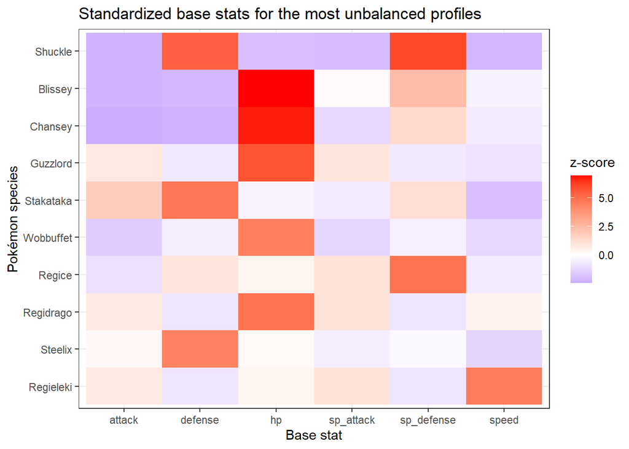

```r
z_df <- as.data.frame(z_stats)
z_df$name <- pokemon$name

z_long <- z_df %>%
  filter(name %in% top_imbalance$name) %>%
  pivot_longer(cols = all_of(base_stats), names_to = "stat", values_to = "z")

ggplot(z_long, aes(x = stat, y = reorder(name, -match(name, top_imbalance$name)), fill = z)) +
  geom_tile() +
  scale_fill_gradient2(low = "blue", mid = "white", high = "red", midpoint = 0) +
  labs(x = "Base stat", y = "Pokémon species", fill = "z-score",
       title = "Standardized base stats for the most unbalanced profiles") +
  theme_bw()
```

##### Exploration of the special status of Pokémon

**COMMENT:** Here we explore the characteristics of the different types of special Pokémon. The aim is to assess if the groups of mythical, legendary and sub-legendary are similar in their characteristics, and if it is sensible to use a single category for legendary and sub-legendary.

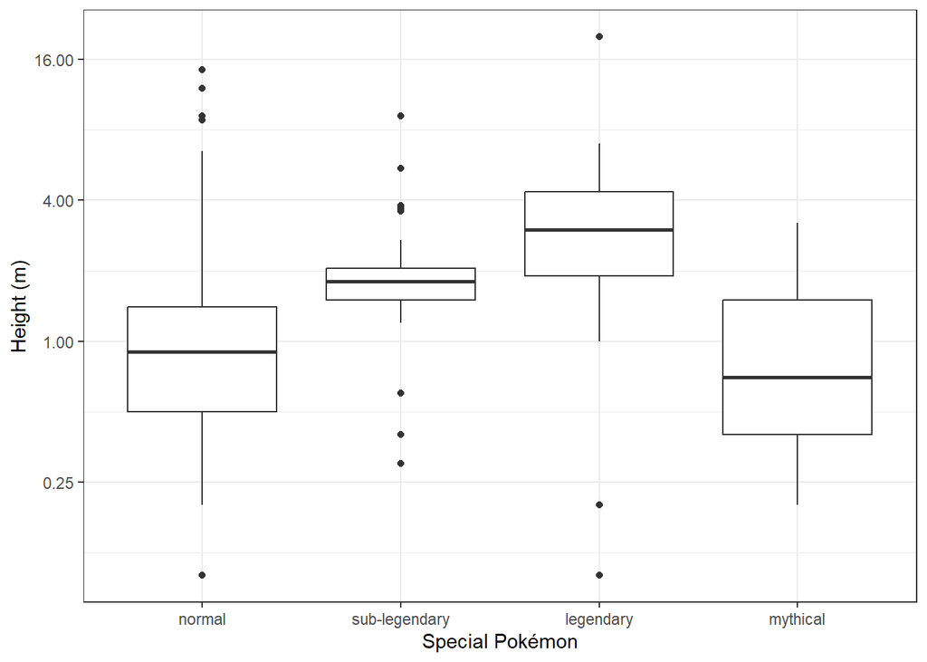

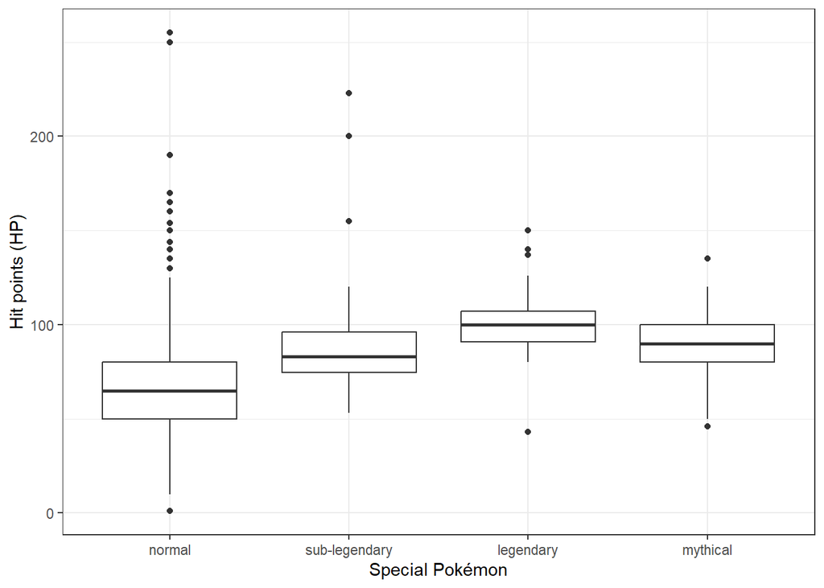

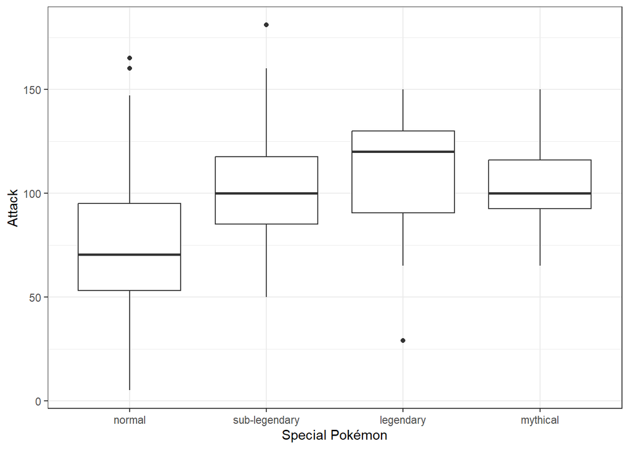

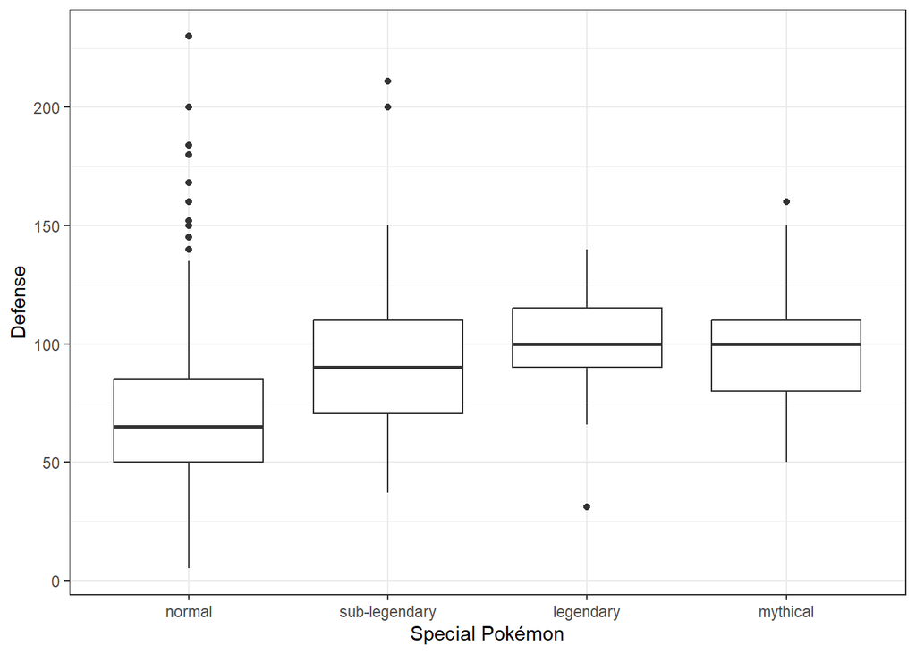

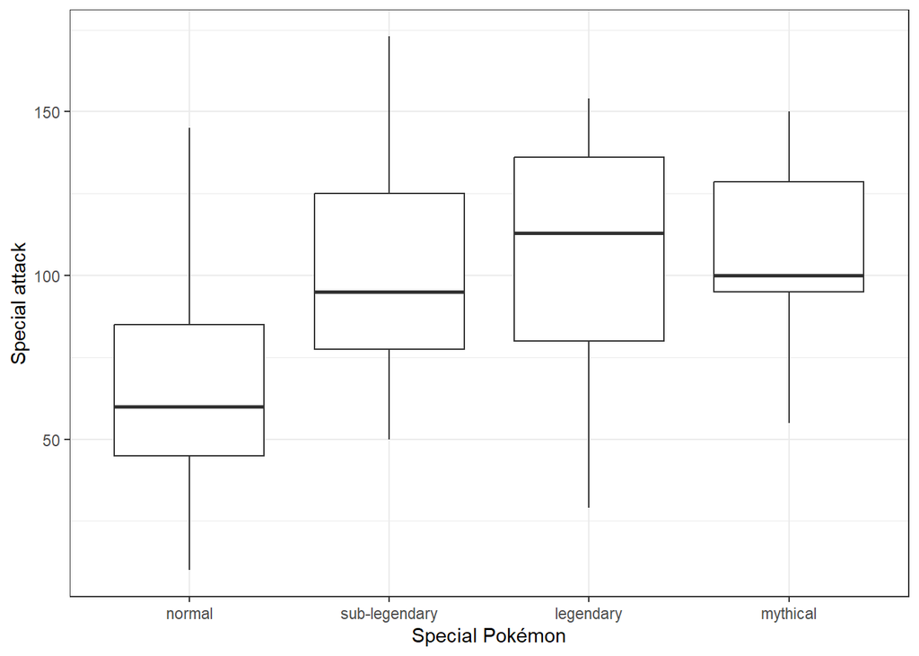

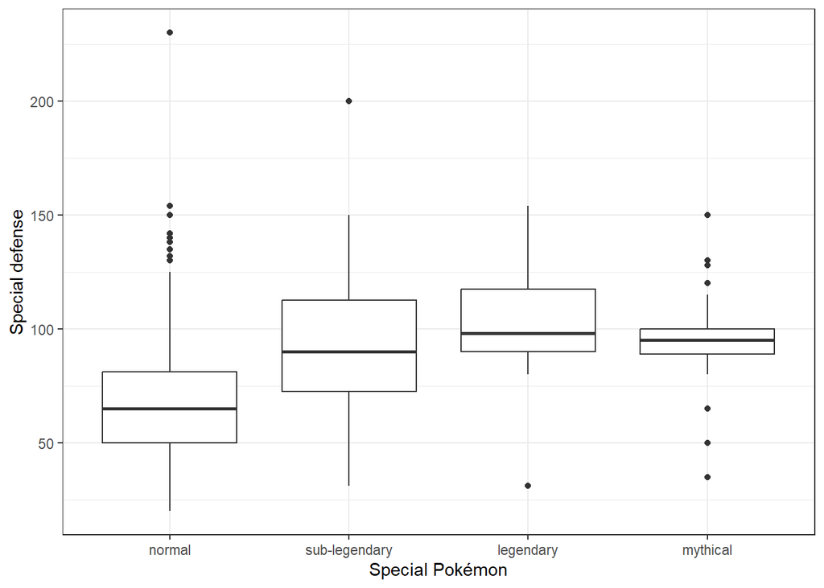

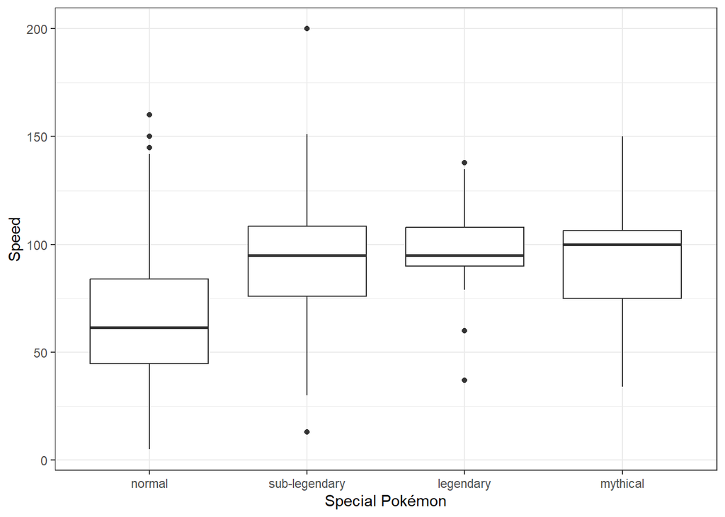

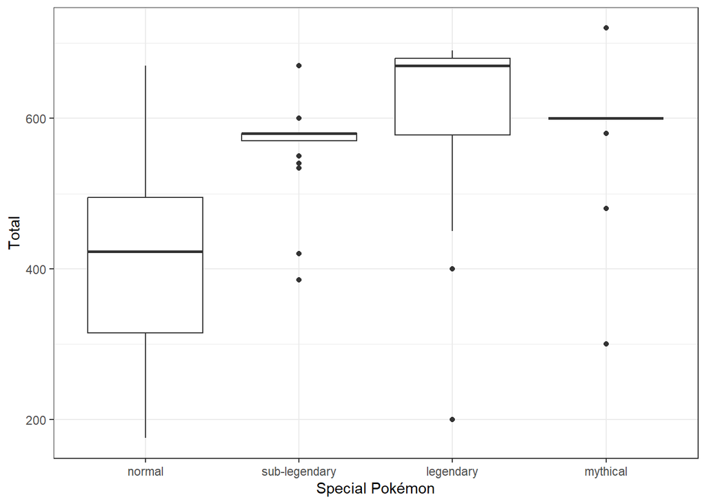

**RESULTS:** The three special types differ among each other in several aspects. In terms of height, mythical are similar to normal and are are considerably shorter than sub-legendary, which are shorter than legendary. Mythical have very homogeneous values of total (almost all have value 600), legendary have larger values, sub-legendary smaller (and rather homogeneous); the difference between the base stats is less pronounced.

**CONSEQUENCE:** The differences observed between the three groups seem to indicate that it is sensible to maintain the three special groups separate in modeling, if the special status is used as an explanatory variable.

The strong separation of subgroups (especially legendary and sub-legendary) in terms of height might be problematic in modeling, as it is possible that the inclusion of this variable in modeling might inflate the standard errors of the height-related regression coefficient; if the groups are associated to weight beyond the differences due to height, it is also possible that some spurious associations between the groups and the outcomes will be estimated.

Also, the interpretation of the regression coefficients from the multivariable model might be problematic (as they refer to comparisons among species of same height but with different status).

##### Exploration of the happiness of Pokémon

**COMMENT:** Here we explore the characteristics of the different happiness categories of Pokémon. The aim is to assess how the groups of unhappy / normal and happy Pokémon differ to gain insight about the potential usefulness of the variable as an explanatory variable.

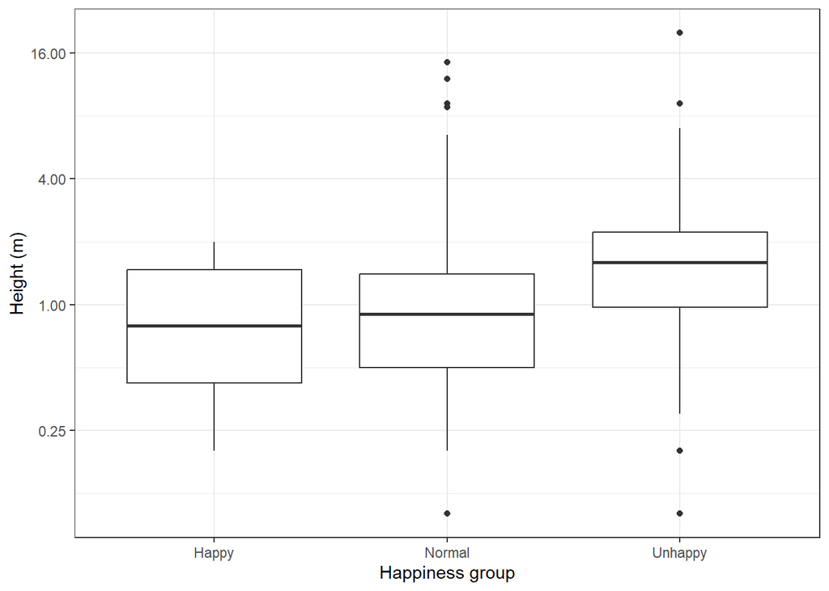

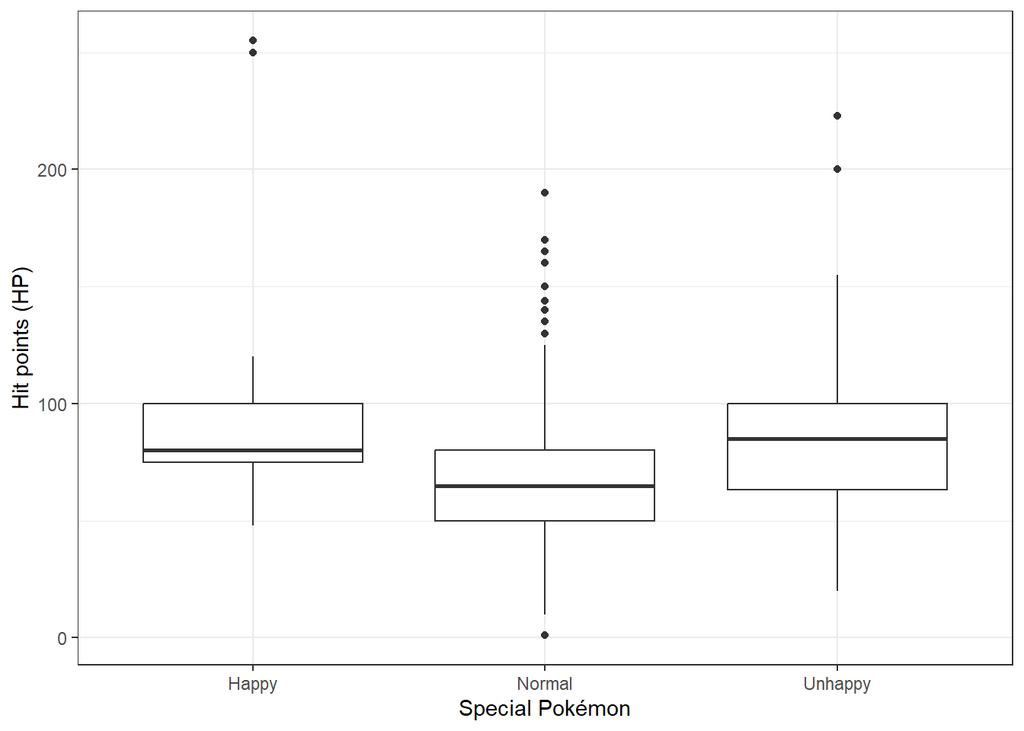

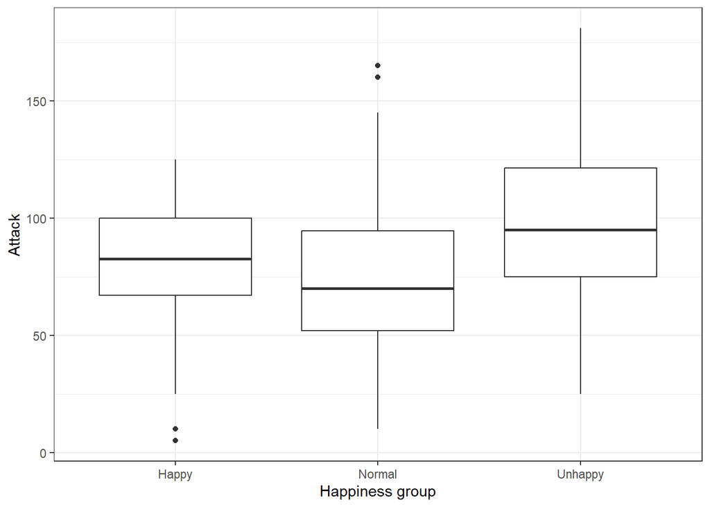

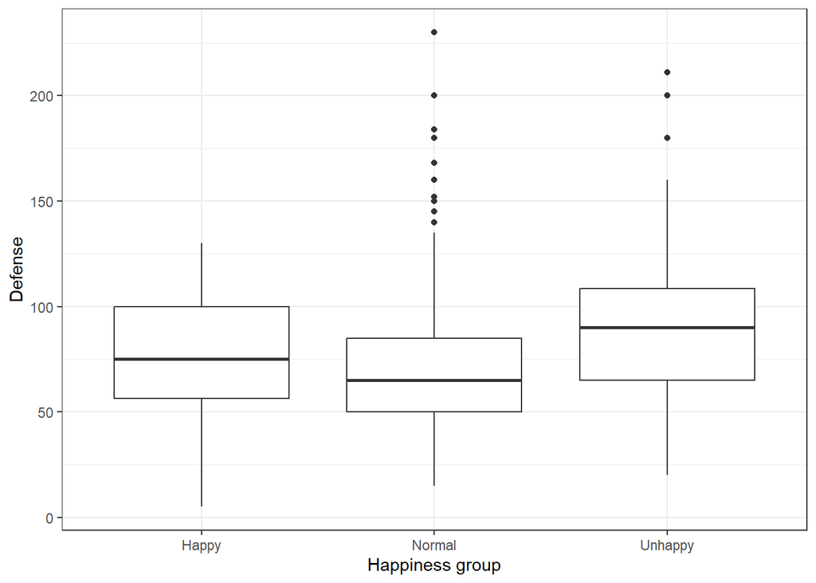

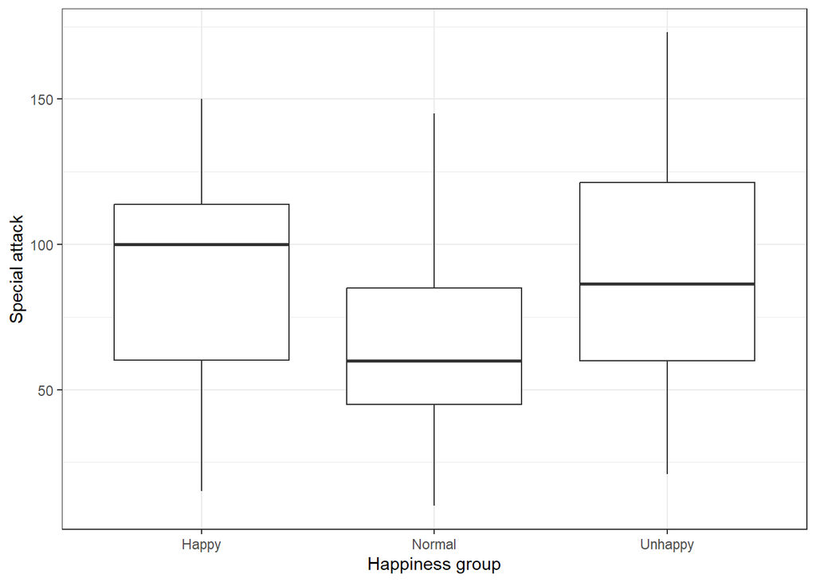

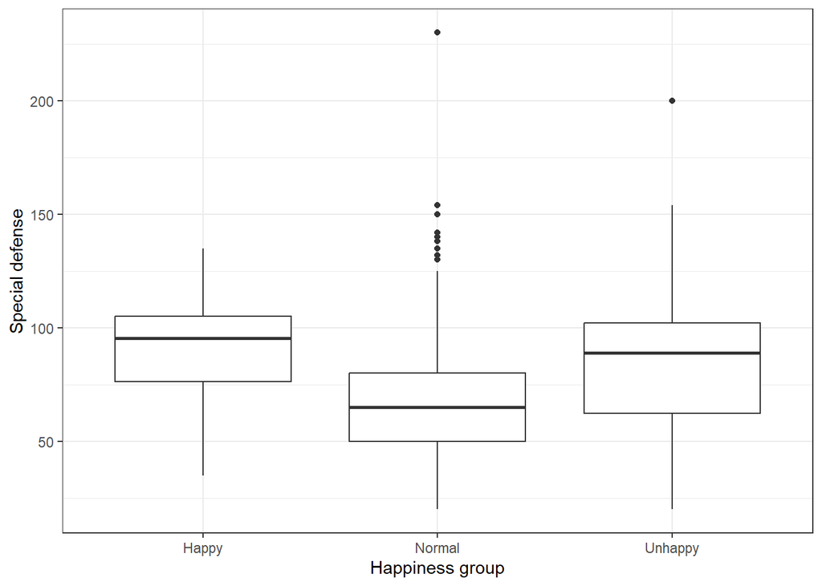

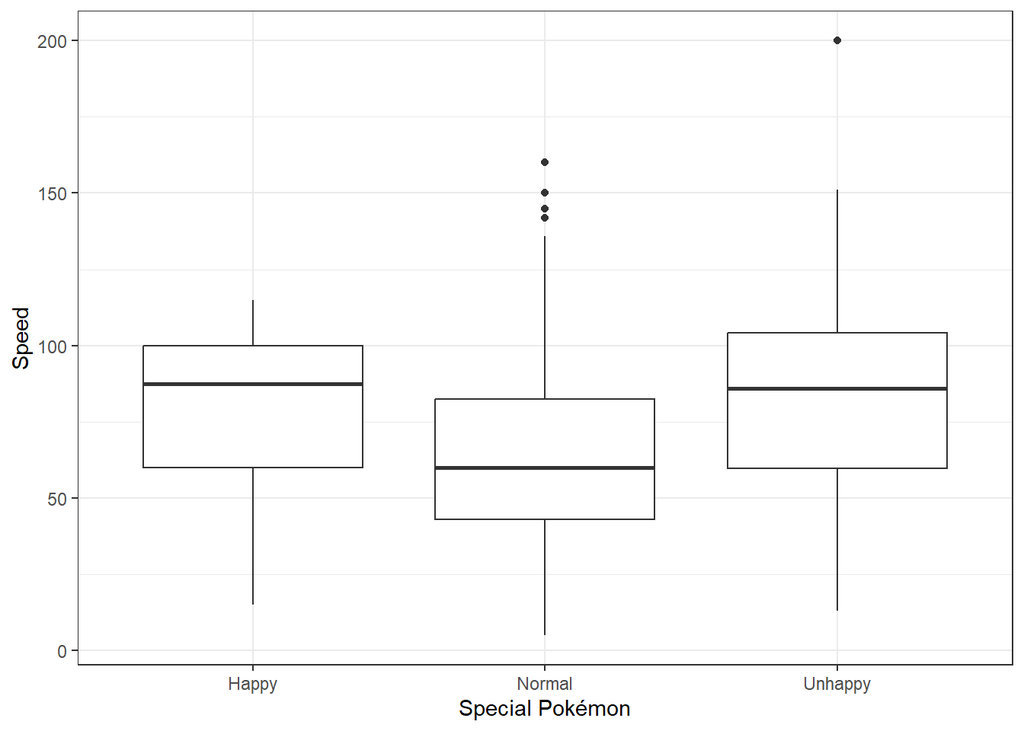

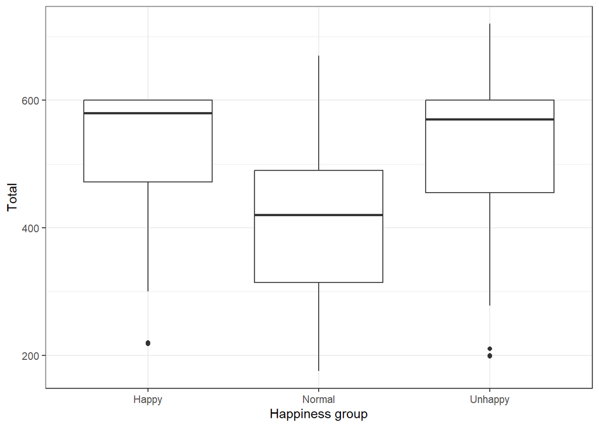

**RESULTS:** The three happiness groups differ among each other in several aspects, it might be unexpected that the happy and unhappy group are similar, and differ from the normal group in most characteristics. Normal types are weaker than happy/unhappy in all aspects, however the height of normal and happy is similar, and unhappy are higher.

**CONSEQUENCE:** Happiness group might contribute some additional information compared to the other explanatory variables. These explorations indicate also that a non-linear relationship might be expected between the outcome and the numerical variable and, due also to the limited number of distinct values, the categorization of the variable might prove beneficial.

##### Clustering of the Pokémon based on the explanatory variables

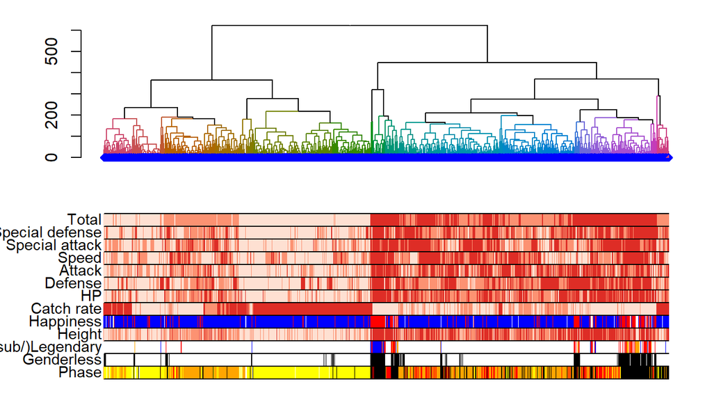

```r
# new version of the graph

  clust.compl <- hclust(dist(pokemon[,12:18]), method="complete")
#  table(cutree(clust.compl, h=150))

  nodePar <- list(lab.cex = 0.6, pch = c(NA, 5),
                   cex = 0.7, col = "blue")

  #plot(dend1, nodePar = nodePar, leaflab = "none")


  par(mfrow=c(1,1))
  par(mar = c(12,4,1,1))

  #save the results in the format dealt with by library library(dendextend)
  dend <- as.dendrogram(hclust(dist(pokemon[,12:18]), method="complete"), nodePar = nodePar, leaflab = "none")

  dend1 <- color_branches(dend, h=150)

  #library(magrittr)
  #dend1 <- dend1 %>% set("labels_cex", .25)


  #divide the values of some of the variables in 3 groups for color coding of the values for the individuals
  #cols3 <- diverging_hcl(3, h = c(240, 0))
  #cols3 <- inferno(3)

  cols3 <- brewer.pal(3, name="Reds")

  colhp <- (cols3[cut(pokemon$hp, breaks=quantile(pokemon$hp, c(0, 0.33, 0.66, 1)), include.lowest=TRUE)])
  colspeed <- (cols3[cut(pokemon$speed, breaks=quantile(pokemon$speed, c(0, 0.33, 0.66, 1)), include.lowest=TRUE)])
  colattack <- (cols3[cut(pokemon$attack, breaks=quantile(pokemon$attack, c(0, 0.33, 0.66, 1)), include.lowest=TRUE)])
  colspatt <- (cols3[cut(pokemon$sp_attack, breaks=quantile(pokemon$sp_attack, c(0, 0.33, 0.66, 1)), include.lowest=TRUE)])
  colspdef <- (cols3[cut(pokemon$sp_defense, breaks=quantile(pokemon$sp_defense, c(0, 0.33, 0.66, 1)), include.lowest=TRUE)])
  colstotal <- (cols3[cut(pokemon$total, breaks=quantile(pokemon$total, c(0, 0.33, 0.66, 1)), include.lowest=TRUE)])
  colsdef <- (cols3[cut(pokemon$defense, breaks=quantile(pokemon$defense, c(0, 0.33, 0.66, 1)), include.lowest=TRUE)])
  colsweight <- (cols3[cut(pokemon$weight_kg, breaks=quantile(pokemon$weight_kg, c(0, 0.33, 0.66, 1)), include.lowest=TRUE)])
  colsheight <- (cols3[cut(pokemon$height_m, breaks=quantile(pokemon$height_m, c(0, 0.33, 0.66, 1)), include.lowest=TRUE)])
  colsev <- c("white", "yellow", "orange", "red", "black")[pokemon$PokemonPhase_5cat]
  colleg <- c("white", "yellow", "orange", "red")[factor(pokemon$special_status)]
  colUnknowGender <- c("white", "black")[factor(pokemon$gender_unknown)]
  colmit <- c("white", "red", "blue", "orange")[factor(pokemon$special_status)] #white: normal, red: legendary, blue" mythical, orange: sub-legendary
  colshappy <-  c("white", "blue", "red")[factor(pokemon$happiness_cat)]
  colcapt <- (cols3[cut(pokemon$catch_rate, breaks=quantile(pokemon$catch_rate, c(0, 0.33, 0.66, 1)), include.lowest=TRUE)])
 # coltype <- factor(pokemon$typeCards1)


  plot(dend1, nodePar = nodePar, leaflab = "none")

  colored_bars(cbind(colsev, colUnknowGender, colmit, #coltype,
                     #pokemon$type1,
                     colsheight, colshappy, colcapt, colhp,colsdef, colattack, colspeed, colspatt,  colspdef, colstotal), dend1,
               rowLabels=c("Phase", "Genderless", "Mythical/(sub/)Legendary", #"Type",
                           #"Type1",
                           "Height", "Happiness", "Catch rate", "HP", "Defense", "Attack", "Speed", "Special attack", "Special defense",
                                                                     "Total"))
```

**RESULTS:** This alternative graphical display confirms the findings from previous data explorations. For example, one group includes most of the legendary/mythical Pokémon that tend to cluster together, most of genderless Pokémon, and exhibits large values of the base stats; this group includes a large proportion of happy and unhappy Pokémon. Roughly, the other three groups are mostly expressing the differences in evolution phases. The association of base stats with their total can be also observed. For example, large values of speed can be observed also for Pokémon that have low overall base stats.

## IDA Result: Analysis-ready dataset

Save out analysis-ready dataset: here we save a copy of the newly defined data sets, where some additional variables were defined based on the results from IDA.

```r
saveRDS(pokemon,"../Data/Pokemon_afterIDA.Rdata")
```